# Exercise_MLPR2023_Part1_fcfb5b21-9fc7-11ed-8f5e-a0487b8f5ed5

This is the template for the image recognition exercise.  
Some **general instructions**, read these carefully:

- The final assignment is returned as a clear and understandable *report*
  - define shortly the concepts and explain the phases you use
  - use the Markdown feature of the notebook for larger explanations
- return your output as a *working* Jupyter notebook
- name your file as Exercise_MLPR2023_Partx_uuid.jpynb
  - use the uuid code determined below
  - use this same code for each part of the assignment
- write easily readable code with comments
  - if you exploit code from web, provide a reference
- it is ok to discuss with a friend about the assignment. But it is not ok to copy someone's work. Everyone should submit their own implementation
  - in case of identical submissions, both submissions are failed

**Deadlines:**

- Part 1: Mon 6.2 at 23:59
- Part 2: Mon 20.2 at 23:59
- Part 3: Mon 6.3 at 23:59

**No extensions for the deadlines**

- after each deadline, example results are given, and it is not possible to submit anymore

**If you encounter problems, Google first and if you can’t find an answer, ask for help**

- Moodle area for questions
- pekavir@utu.fi
- teacher available for questions
  - Monday 30.1 at 14:00-15:00 room 407B Honka (Agora 4th floor)
  - Monday 13.2 at 14:00-15:00 room 407B Honka (Agora 4th floor)
  - Thursday 2.3 at lecture 10:15-12:00

**Grading**

The exercise covers a part of the grading in this course. The course exam has 5 questions, 6 points of each. Exercise gives 6 points, i.e. the total score is 36 points.

From the template below, you can see how many exercise points can be acquired from each task. Exam points are given according to the table below:

7 exercise points: 1 exam point  
8 exercise points: 2 exam points  
9 exercise points: 3 exam points  
10 exercise points: 4 exam points  
11 exercise points: 5 exam points  
12 exercise points: 6 exam points  
To pass the exercise, you need at least 7 exercise points, and at least 1 exercise point from each Part.

Each student will grade one submission from a peer and their own submission. After each Part deadline, example results are given. Study them carefully and perform the grading according to the given instructions. Mean value from the peer grading and self-grading is used for the final points.

```python
import uuid
# Run this cell only once and save the code. Use the same id code for each Part.
# Printing random id using uuid1()
print ("The id code is: ",end="")
print (uuid.uuid1())
```

```
The id code is: 05874650-a2da-11ed-a607-a0487b8f5ed5
```

# Part 1

Read the original research article:

İ. Çınar and M. Koklu. Identification of rice varieties using machine learning algorithms. Journal of Agricultural Sciences, 28(2):307–325, 2022. doi: 10.15832/ankutbd.862482.

https://dergipark.org.tr/en/download/article-file/1513632

## Introduction (1 p)

Will be written in Part 3

## Preparations of the data (1 p)

Make three folders in your working folder: "notebooks", "data" and "training_data". Save this notebook in "notebooks" folder.  
Perform preparations for the data

- import all the packages needed for this notebook in one cell
- import the images. Data can be found from (downloading starts as you press the link) https://www.muratkoklu.com/datasets/vtdhnd09.php
  - save the data folders "Arborio", "Basmati" and "Jasmine" in "data" folder
- take a random sample of 100 images from Arborio, Basmati and Jasmine rice species (i.e. 300 images in total)
- determine the contour of each rice (you can use e.g. *findContours* from OpenCV)
- plot one example image of each rice species, including the contour

## Feature extraction (2 p)

Gather the feature data

Color features (15)  
- Calculate the following color features for each image, including only the pixels within the contour (you can use e.g. *pointPolygonTest* from OpenCV) - Mean for each RGB color channel - Variance for each RGB color channel - Skewness for each RGB color channel - Kurtosis for each RGB color channel - Entropy for each RGB color channel

Dimension features (6)

- Fit an ellipse to the contour points (you can use e.g. *fitEllipse* from OpenCV)
- Plot one example image of each rice species including the fitted ellipse
- Calculate the following features for each image (for details, see the original article)
  - the major axis length the ellipse
  - the minor axis length of the ellipse
  - area inside the contour (you can use e.g. *contourArea* from OpenCV)
  - perimeter of the contour (you can use e.g. *arcLength* from OpenCV)
  - roundness
  - aspect ratio

Gather all the features in one array or dataframe: one data point in one row, including all feature values in columns.  
For each data point, include also information of the original image and the label (rice species). Save the data in "training_data" folder.

```python
# Importing required libraries

import pandas as pd
import numpy as np
import cv2 as cv
import matplotlib.pyplot as plt
from glob import glob
import random
import math
import os
from scipy.stats import kurtosis, skew, entropy
```

## Importing data and creating dataframe

```python
# Importing 100 random images from all three rice species

arborio = pd.DataFrame(random.sample(glob('../data/Arborio/*.jpg'), 100), columns = ['path'])
arborio['label'] = 'arborio'
basmati = pd.DataFrame(random.sample(glob('../data/Basmati/*.jpg'), 100), columns = ['path'])
basmati['label'] = 'basmati'
jasmine = pd.DataFrame(random.sample(glob('../data/Jasmine/*.jpg'), 100), columns = ['path'])
jasmine['label'] = 'jasmine'
```

```python
df = pd.concat([arborio, basmati, jasmine], axis = 0)
df.sample(10)
```

|  | path | label |
| --- | --- | --- |
| 41 | ../data/Arborio\Arborio (403).jpg | arborio |
| 39 | ../data/Jasmine\Jasmine (12808).jpg | jasmine |
| 34 | ../data/Basmati\basmati (10009).jpg | basmati |
| 4 | ../data/Jasmine\Jasmine (860).jpg | jasmine |
| 12 | ../data/Basmati\basmati (10444).jpg | basmati |
| 5 | ../data/Basmati\basmati (10551).jpg | basmati |
| 33 | ../data/Arborio\Arborio (12799).jpg | arborio |
| 19 | ../data/Basmati\basmati (11970).jpg | basmati |
| 15 | ../data/Arborio\Arborio (12377).jpg | arborio |
| 23 | ../data/Basmati\basmati (1041).jpg | basmati |

## Plotting original images with contours (one from each rice species)

```python
data = df.groupby('label').sample(1)
data
```

|  | path | label |
| --- | --- | --- |
| 90 | ../data/Arborio\Arborio (3724).jpg | arborio |
| 12 | ../data/Basmati\basmati (10444).jpg | basmati |
| 30 | ../data/Jasmine\Jasmine (3829).jpg | jasmine |

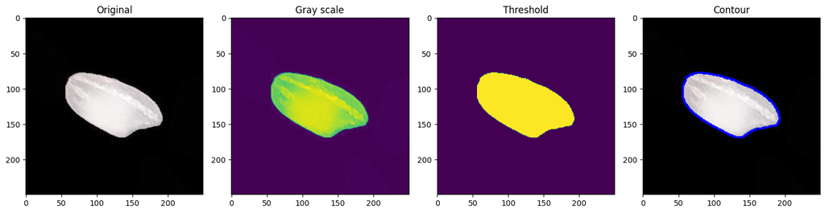

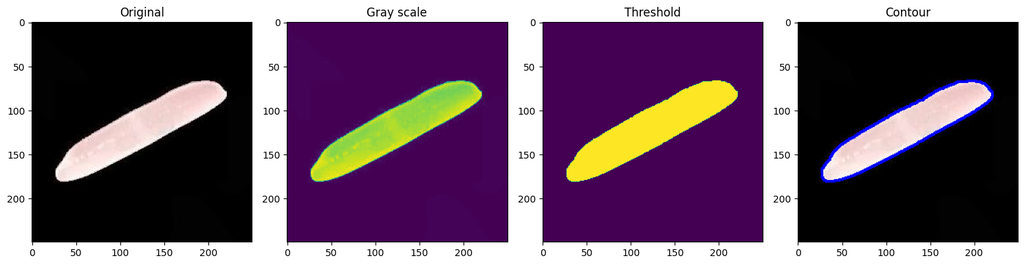

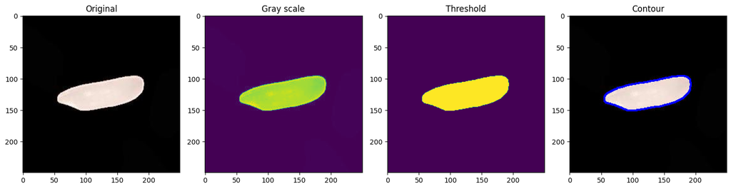

```python
for i, row in data.iterrows():
    image = cv.imread(row['path'])
    fig, ax = plt.subplots(1, 4, figsize=(15, 15))

    # Original Image
    ax[0].set_title("Original")
    ax[0].imshow(image)

    # Converting original image to gray scale
    img = cv.cvtColor(image, cv.COLOR_BGR2GRAY)
    ax[1].set_title("Gray scale")
    ax[1].imshow(img)

    # Threshold of the gray image
    ret, thresh = cv.threshold(img, 125, 255, 0)
    ax[2].set_title("Threshold")
    ax[2].imshow(thresh)

    # Finding contours
    contours, hierarchy = cv.findContours(thresh, cv.RETR_TREE, cv.CHAIN_APPROX_SIMPLE)

    # Drawing contours
    copy = image.copy()
    cv.drawContours(copy, contours, -1, (0,0,255), 2)
    ax[3].set_title("Contour")
    ax[3].imshow(copy)

    plt.tight_layout()
```

## Feature extraction

```python
for index, row in df.iterrows():

    # Finding and drawing contours on a copy of the original image
    image = cv.imread(row['path'])
    gray_image = cv.cvtColor(image, cv.COLOR_BGR2GRAY)
    ret, thresh = cv.threshold(gray_image, 125, 255, 0)
    contours, hierarchy = cv.findContours(thresh, cv.RETR_TREE, cv.CHAIN_APPROX_SIMPLE)
    image_copy = image.copy()
    cv.drawContours(image_copy, contours, -1, (0,0,255), 2)

    # Fitting ellipse to the contours points
    ellipse = cv.fitEllipse(contours[0])
    cv.ellipse(image_copy, ellipse, (0, 0, 255), 3)

    # Saving new image with contours and ellipse
    image_name = row['path'].split(os.path.sep)[1]
    path = f'../data/Contours/{image_name}'
    cv.imwrite(path, image_copy)
    df.at[index, 'contour_path'] = path

    # Calculating major and minor axis length, contour area, contour perimeter
    (xc, yc), (d1, d2), angle = ellipse
    df.at[index, 'major_axis'] = max(d1, d2)/2
    df.at[index, 'minor_axis'] = min(d1, d2)/2
    area = cv.contourArea(contours[0])
    df.at[index, 'area'] = area
    x,y,w,h = cv.boundingRect(contours[0])
    df.at[index, 'aspect_ratio'] = float(w)/h
    perimeter = cv.arcLength(contours[0], True)
    df.at[index, 'perimeter'] = perimeter
    df.at[index, 'roundness'] = (4 * area * math.pi) / perimeter ** 2
```

## Plotting images with contours and ellipse (one from each rice species)

```python
data = df.groupby('label').sample(1)
data
```

|  | path | label | contour_path | major_axis | minor_axis | area | aspect_ratio | perimeter | roundness |
| --- | --- | --- | --- | --- | --- | --- | --- | --- | --- |
| 46 | ../data/Arborio\Arborio (13016).jpg | arborio | ../data/Contours/Jasmine (8882).jpg | 75.747795 | 23.559511 | 5347.5 | 1.436782 | 339.747254 | 0.582169 |
| 45 | ../data/Basmati\basmati (9548).jpg | basmati | ../data/Contours/Jasmine (6448).jpg | 79.020508 | 22.216085 | 5361.5 | 2.393443 | 355.521860 | 0.533045 |
| 55 | ../data/Jasmine\Jasmine (1879).jpg | jasmine | ../data/Contours/Jasmine (1879).jpg | 83.230804 | 22.134804 | 5356.5 | 1.198113 | 366.658943 | 0.500687 |

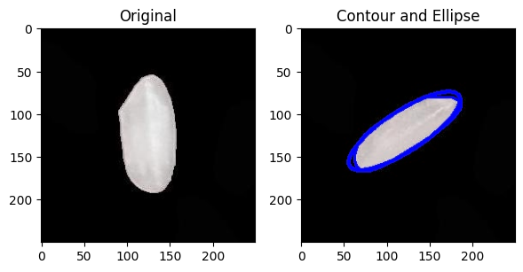

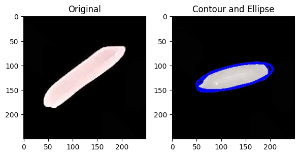

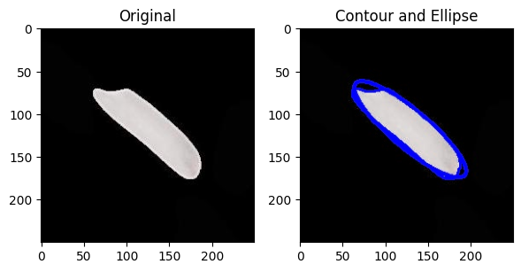

```python
for i, row in data.iterrows():
    fig, ax = plt.subplots(1, 2, figsize=(6, 6))

    # Original Image
    image = cv.imread(row['path'])
    ax[0].set_title("Original")
    ax[0].imshow(image)

    # Images with contours and ellipse
    image_new = cv.imread(row['contour_path'])
    ax[1].set_title("Contour and Ellipse")
    ax[1].imshow(image_new)

    plt.tight_layout()
```

```python
for index, row in df.iterrows():

    # Finding contours
    image = cv.imread(row['path'])
    gray_image = cv.cvtColor(image, cv.COLOR_BGR2GRAY)
    ret, thresh = cv.threshold(gray_image, 125, 255, 0)
    contours, hierarchy = cv.findContours(thresh, cv.RETR_TREE, cv.CHAIN_APPROX_SIMPLE)

    # Check if the pixel falls inside the contour
    R,G,B = [], [], []
    for x in range(image.shape[0]):
        for y in range(image.shape[1]):
            if cv.pointPolygonTest(contours[0], (y,x), False) > 0:
                R.append(image[y,x,0])
                G.append(image[y,x,1])
                B.append(image[y,x,2])

    # Creating new features
    df.at[index, 'RGB_R_mean'] = np.mean(np.array(R))
    df.at[index, 'RGB_G_mean'] = np.mean(np.array(G))
    df.at[index, 'RGB_B_mean'] = np.mean(np.array(B))

    df.at[index, 'RGB_R_kurtosis'] = kurtosis(np.array(R))
    df.at[index, 'RGB_G_kurtosis'] = kurtosis(np.array(G))
    df.at[index, 'RGB_B_kurtosis'] = kurtosis(np.array(B))

    df.at[index, 'RGB_R_skew'] = skew(np.array(R))
    df.at[index, 'RGB_G_skew'] = skew(np.array(G))
    df.at[index, 'RGB_B_skew'] = skew(np.array(B))

    df.at[index, 'RGB_R_entropy'] = entropy(np.array(R))
    df.at[index, 'RGB_G_entropy'] = entropy(np.array(G))
    df.at[index, 'RGB_B_entropy'] = entropy(np.array(B))

    df.at[index, 'RGB_R_var'] = np.var(np.array(R))
    df.at[index, 'RGB_G_var'] = np.var(np.array(G))
    df.at[index, 'RGB_B_var'] = np.var(np.array(B))
```

```python
df.sample(5)
```

|  | path | label | contour_path | major_axis | minor_axis | area | aspect_ratio | perimeter | roundness | RGB_R_mean | ... | RGB_B_kurtosis | RGB_R_skew | RGB_G_skew | RGB_B_skew | RGB_R_entropy | RGB_G_entropy | RGB_B_entropy | RGB_R_var | RGB_G_var | RGB_B_var |
| --- | --- | --- | --- | --- | --- | --- | --- | --- | --- | --- | --- | --- | --- | --- | --- | --- | --- | --- | --- | --- | --- |
| 27 | ../data/Arborio\Arborio (12213).jpg | arborio | ../data/Contours/Jasmine (13180).jpg | 109.601311 | 30.086246 | 9908.0 | 2.451220 | 491.705625 | 0.514974 | 85.055945 | ... | -1.583718 | 0.631786 | 0.631864 | 0.633505 | 8.156718 | 8.153395 | 8.150825 | 13164.853394 | 12600.351309 | 10526.455563 |
| 1 | ../data/Basmati\basmati (11190).jpg | basmati | ../data/Contours/Jasmine (2495).jpg | 76.048798 | 22.520107 | 5239.0 | 0.489209 | 349.906635 | 0.537717 | 104.036957 | ... | -1.929555 | 0.232903 | 0.233842 | 0.233463 | 7.754606 | 7.743639 | 7.742212 | 13210.385896 | 11923.812321 | 11794.622063 |
| 82 | ../data/Arborio\Arborio (6902).jpg | arborio | ../data/Contours/Jasmine (6161).jpg | 77.577217 | 24.314489 | 5685.5 | 1.207921 | 352.031525 | 0.576521 | 160.423417 | ... | -1.035599 | -0.961560 | -0.960107 | -0.960266 | 8.313219 | 8.307057 | 8.307133 | 9677.444929 | 9287.174014 | 9279.314175 |
| 44 | ../data/Jasmine\Jasmine (6665).jpg | jasmine | ../data/Contours/Jasmine (6665).jpg | 79.304031 | 22.728359 | 5562.5 | 2.620690 | 362.693432 | 0.531374 | 83.705240 | ... | -1.649692 | 0.577567 | 0.577827 | 0.578044 | 7.611721 | 7.601948 | 7.601297 | 12039.656497 | 10990.620048 | 11006.936264 |
| 39 | ../data/Jasmine\Jasmine (12808).jpg | jasmine | ../data/Contours/Jasmine (12808).jpg | 112.323990 | 30.510136 | 10204.5 | 2.292135 | 498.232535 | 0.516580 | 99.205788 | ... | -1.789121 | 0.442259 | 0.442902 | 0.445778 | 8.295678 | 8.292744 | 8.290333 | 14975.013630 | 14992.401953 | 12536.931613 |

5 rows × 24 columns

```python
df.to_csv('../training_data/data.csv')
```